# Bios26121: Homework 4

# Problem 1: Multiple testing

In the previous homework, we focused on a pair of genes to illustrate two aspects of variation. One of the genes appeared to have high between-mouse variation that was hidden in the act of pooling samples within strain. When strains were compared on the basis of the pooled data, there was an appearance of a significant strain effect for this gene ($p < 10^{-6}$), but when individual-level data were used to perform the comparison, the strain effect was found to be very weak at best ($p = 0.089$). The lesson is to recognize that the most scientifically compelling questions concern biological variation, which can only be directly measured with good experimental design. Accurate interpretation of origin and size of biological variation requires appropriate statistical analysis.

Here we will cover inference in the context of genome-scale experiments. There are several serious conceptual problems:

- there are many tests, often at least one test for each one of tens of thousands of features
- each feature (typically a gene) exhibits its own technical and biological variability
- there may be unmeasured or unreported sources of biological variation (such as time of day)
- many features are inherently interrelated, so the tests are not independent

We start by loading the pooling experiment data

```r
library(Biobase)
library(maPooling)
data(maPooling)
pd=pData(maPooling)
individuals=which(rowSums(pd)==1)
```

And extracting the individual mice as well as their strain

```r
individuals=which(rowSums(pd)==1)
individuals=individuals[-grep("tr",names(individuals))]
y=exprs(maPooling)[,individuals]
g=factor(as.numeric(grepl("b",names(individuals))))
```

## T-tests

We can now apply a t-test to each gene using the `rowttest` function in the `genefilter` package. The function has much faster implementation for multiple t-tests.

```r
library(genefilter)
tt=rowttests(y,g)
```

**Question**:

- For somewhat arbitrary reasons, in science p-values of 0.01 and 0.05 are used as cutoff. Now how many genes do we report as statistically significant using a cutoff of 0.01 or 0.05? The p-values are stored in `tt$p.value`.

```r
NsigAt01 = sum(tt$p.value<0.01)
NsigAt01
```

```
## [1] 1578
```

```r
NsigAt05 = sum(tt$p.value<0.05)
NsigAt05
```

```
## [1] 2908
```

# Multiple testing

Do we report all the nominally significant genes identified above? Let’s explore what happens if we split the first group into two, forcing the null hypothesis to be true

```r
set.seed(0)
shuffledIndex <- factor(sample(c(0,1),sum(g==0),replace=TRUE ))
nulltt <- rowttests(y[,g==0],shuffledIndex)
NfalselySigAt01 = sum(nulltt$p.value<0.01)
NfalselySigAt01
```

```
## [1] 79
```

```r
NfalselySigAt05 = sum(nulltt$p.value<0.05)
NfalselySigAt05
```

```
## [1] 840
```

**Questions**:

- What is the null hypothesis? Why the above code can force the null hypothesis to be true? Now how many genes do we report as statistically significant using a cutoff of 0.01 or 0.05 when forcing the null hypothesis to be true (The p-values are stored in `nulltt$p.value`)? What is a false positive discovery? If we use the 0.05 cutoff we will be reporting **?** false positives.
- There are several ways to adjust for this including methods availale in function `p.adjust`. After fdr adjustment do we acquire a smaller list of genes? Can you also make the adjustemt using Bonferroni’s method? Which one is more stringent? Which one will you use in gene expression analysis? Why?

```r
qvals = p.adjust(tt$p.value, method="fdr")
sum(qvals<0.05)
```

```
## [1] 1123
```

```r
sum(qvals<0.01)
```

```
## [1] 498
```

- Now how many false positives are there in the null case after adjustment?

```r
nullqvals = p.adjust(nulltt$p.value, method="fdr")
sum(nullqvals<0.05)
```

```
## [1] 0
```

```r
sum(nullqvals<0.01)
```

```
## [1] 0
```

This addresses in a fairly general way the problem of inflating significance claims when performing many hypothesis tests at a fixed nominal level of significance.

# Problem 2: Unsupervised learning on gene expression data

Machine learning is a very broad topic and a highly active research area. In the life sciences, much of what is described as `precision medicine` is an application of machine learning to biomedical data. The general idea is to predict or discover outcomes from measured predictors. Clustering is a major machine learning component that can be used to answer questions like following: can we discover new types of cancer from gene expression profiles? Can we seperate cell lines or tissues based on gene expression markers?

## Clustering

We will demonstrate the concepts and code needed to perform clustering analysis with the tissue gene expression data:

```r
load("tissuesGeneExpression.rda")
```

#### Hierarchical clustering

With the distance between each pair of samples computed, we need clustering algorithms to join them into groups. Hierarchical clustering is one of the many clustering algorithms available to do this. Each sample is assigned to its own group and then the algorithm continues iteratively, joining the two most similar clusters at each step, and continuing until there is just one group. While we have defined distances between samples, we have not yet defined distances between groups. There are various ways this can be done and they all rely on the individual pairwise distances. The helpfile for `hclust` includes detailed information.

We can perform hierarchical clustering based on the distances defined above using the `hclust` function. This function returns an `hclust` object that describes the groupings that were created using the algorithm described above. The `plot` method represents these relationships with a tree or dendrogram:

```r
d <- dist( t(e) )
library(rafalib)
mypar()
hc <- hclust(d)
hc
```

```
##
## Call:
## hclust(d = d)
##
## Cluster method   : complete
## Distance         : euclidean
## Number of objects: 189
```

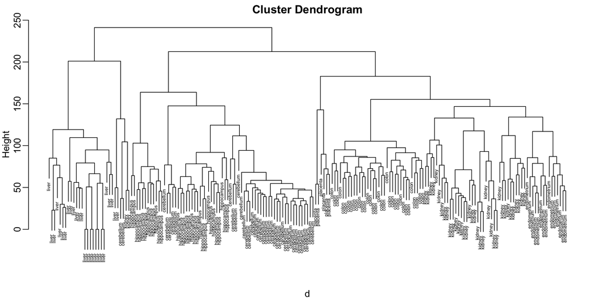

Dendrogram showing hierarchical clustering of tissue gene expression data.

```r
plot(hc,labels=tissue,cex=0.5)
```

Does this technique “discover” the clusters defined by the different tissues? In this plot, it is not easy to see the different tissues so we add colors by using the `myplclust` function from the `rafalib` package.

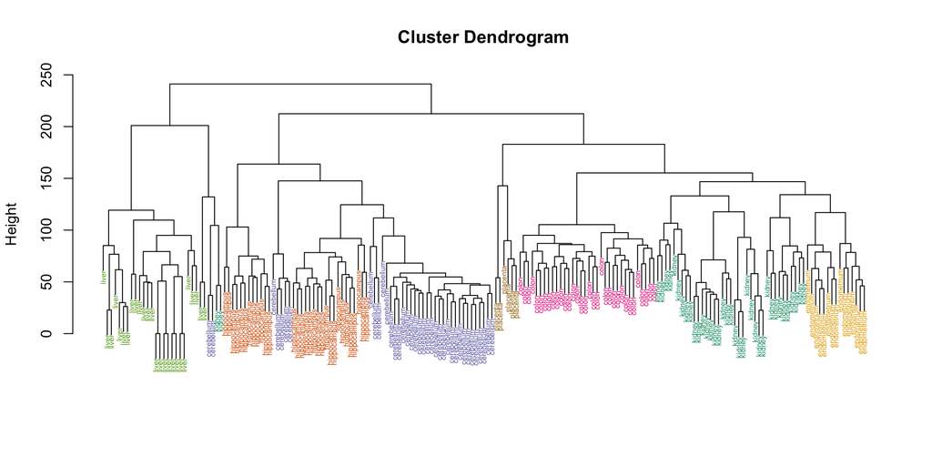

Dendrogram showing hierarchical clustering of tissue gene expression data with colors denoting tissues.

```r
myplclust(hc, labels=tissue, lab.col=as.fumeric(tissue), cex=0.5)
```

Visually, it does seem as if the clustering technique has discovered the tissues. However, hierarchical clustering does not define specific clusters, but rather defines the dendrogram above. From the dendrogram we can decipher the distance between any two groups by looking at the height at which the two groups split into two.

**Questions**: Use `cutree` function:

- Can you cut the tree into 8 clusters? Can you examine how the clusters overlap with the actual tissues using function `table`?

```r
hclusters <- cutree(hc, k=8)
table(true=tissue, cluster=hclusters)
```

```
##              cluster
## true           1  2  3  4  5  6  7  8
##   cerebellum   0  0 31  0  0  2  5  0
##   colon        0  0  0 34  0  0  0  0
##   endometrium 15  0  0  0  0  0  0  0
##   hippocampus  0 12 19  0  0  0  0  0
##   kidney      37  0  0  0  0  2  0  0
##   liver        0  0  0  0 24  2  0  0
##   placenta     0  0  0  0  0  0  0  6
```

- Instead of specifying number of clusters, we can also define clusters by “cutting the tree” at some distance and group all samples that are within that distance into groups below. Can you cut the tree at the height of 120? How the clusters overlap with the actual tissues?

```r
hclusters <- cutree(hc, h=120)
table(true=tissue, cluster=hclusters)
```

```
##              cluster
## true           1  2  3  4  5  6  7  8  9 10 11 12 13 14
##   cerebellum   0  0  0  0 31  0  0  0  2  0  0  5  0  0
##   colon        0  0  0  0  0  0 34  0  0  0  0  0  0  0
##   endometrium  0  0  0  0  0  0  0  0  0  0 15  0  0  0
##   hippocampus  0  0 12 19  0  0  0  0  0  0  0  0  0  0
##   kidney       9 18  0  0  0 10  0  0  2  0  0  0  0  0
##   liver        0  0  0  0  0  0  0 24  0  2  0  0  0  0
##   placenta     0  0  0  0  0  0  0  0  0  0  0  0  2  4
```

- Can you perform hierachical clustering using a different agglomeration method? Check `method` option in the `hclust` function for possibilities. Do you get same result using an alternative method? What does it imply in real data analysis when you have different choices of agglomeration methods and distance metrics?

#### K-means

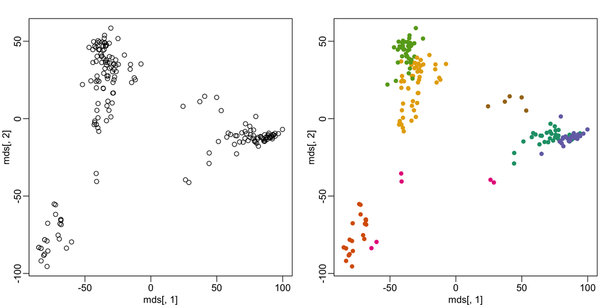

```r
km <- kmeans(t(e), centers=7)
mds <- cmdscale(d)
mypar(1,2)
plot(mds[,1], mds[,2])
plot(mds[,1], mds[,2], col=km$cluster, pch=16)
```

**Questions**:

- What do you observe from the MDS plot? Do we obtain a similar answer to that obtained with hierarchical clustering? Confirm by tabulating the results.

```r
table(true=tissue,cluster=km$cluster)
```

```
##              cluster
## true           1  2  3  4  5  6  7
##   cerebellum   0  0 31  2  0  0  5
##   colon        0  0  0  0 34  0  0
##   endometrium  0  0  0  0  0 15  0
##   hippocampus 31  0  0  0  0  0  0
##   kidney       0  0  0  2  0 37  0
##   liver        0 24  0  2  0  0  0
##   placenta     0  0  0  0  6  0  0
```

#### Heatmaps

Heatmaps are ubiquitous in the genomics literature. They are very useful plots for visualizing the measurements for a subset of rows over all the samples. A *dendrogram* is added on top and on the side that is created with hierarchical clustering. We will demonstrate how to create heatmaps from within R. Let’s begin by defining a color palette:

```r
library(RColorBrewer)
hmcol <- colorRampPalette(brewer.pal(9, "GnBu"))(100)
```

Now, pick the genes with the top variance over all samples:

```r
library(genefilter)
rv <- rowVars(e)
idx <- order(-rv)[1:40]
```

While a `heatmap` function is included in R, we recommend the `heatmap.2` function from the `gplots` package on CRAN because it is a bit more customized. For example, it stretches to fill the window. Here we add colors to indicate the tissue on the top:

```r
library(gplots) ##Available from CRAN
cols <- palette(brewer.pal(8, "Dark2"))[as.fumeric(tissue)]
head(cbind(colnames(e),cols))
```

```
##                        cols
## [1,] "GSM11805.CEL.gz" "#1B9E77"
## [2,] "GSM11814.CEL.gz" "#1B9E77"
## [3,] "GSM11823.CEL.gz" "#1B9E77"
## [4,] "GSM11830.CEL.gz" "#1B9E77"
## [5,] "GSM12067.CEL.gz" "#1B9E77"
## [6,] "GSM12075.CEL.gz" "#1B9E77"
```

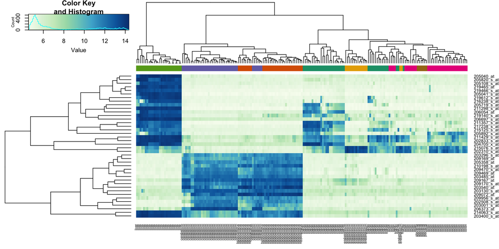

Heatmap created using the 40 most variable genes and the function heatmap.2.

```r
heatmap.2(e[idx,], labCol=tissue,
          trace="none",
          ColSideColors=cols,
          col=hmcol)
```

We did not use tissue information to create this heatmap, and we can quickly see, with just 40 genes, good separation across tissues.

**Questions**:

- Can you create heatmaps using the 100 most variable genes and the 200 most variable genes, respectively? How do your results compare to the heatmap based on 40 genes?
- How does the *dendrogram* on top of your heatmaps compare to that from previous hierarchical clustering analysis?

# Problem 3: Gene set analysis

From the original paper describing the Gene Set Enrichment Analysis:

The goal of GSEA is to determine whether members of a gene set S tend to occur toward the top (or bottom) of the list L, in which case the gene set is correlated with the phenotypic class distinction.

The Gene Set Enrichment Analysis (GSEA) has been around since 2005 and has become a routine analysis step in gene expression analyses. It differs from Gene Ontology enrichment analysis in that it considers all genes in contrast to taking only significantly differentially expressed genes. The fgsea package allows one to conduct a pre-ranked GSEA in R, which is one approach in a GSEA. A p-value is estimated by permuting the genes in a gene set, which leads to randomly assigned gene sets of the same size. Note that “This approach is not strictly accurate because it ignores gene-gene correlations and will overestimate the significance levels and may lead to false positives.” However, it is still useful in getting an idea of the potential roles of the genes that are up- and down-regulated. If your pre-ranked GSEA returns no significant gene sets, you may still get an idea of what roles the up- and down-regulated genes may be involved in by examining the leading edge set. This set indicates the genes that contributed to the enrichment score.

We will be using the fgsea package, so install that first.

```r
## try http:// if https:// URLs are not supported
source("https://bioconductor.org/biocLite.R")
biocLite("fgsea")
library(fgsea)
```

```r
library(fgsea)

data(examplePathways)

# pathways are stored in a list
class(examplePathways)

# the example list has 1,457 "pathways"
length(examplePathways)

# this is the first pathway, which contains
# all the Entrez gene IDs of the Meiotic_Synapsis pathway
examplePathways[1]

data(exampleRanks)

# ranks are stored as a numeric vector
class(exampleRanks)

# the names of the vector are the Entrez gene IDs
head(exampleRanks)

# the values are the rank metric
head(unname(exampleRanks))

# ranks are from lowest to highest
tail(unname(exampleRanks))
```

```r
library(fgsea)
```

```r
library(ggplot2)
data(examplePathways)
data(exampleRanks)
fgseaRes <- fgsea(pathways = examplePathways,
                  stats = exampleRanks,
                  minSize=15,
                  maxSize=500,
                  nperm=100000)

# top 6 enriched pathways
head(fgseaRes[order(pval), ])
```

```
##                                pathway         pval         padj        ES
## 1:                  5990980_Cell_Cycle 1.227898e-05 0.0003025116 0.5388497
## 2:         5990979_Cell_Cycle,_Mitotic 1.254327e-05 0.0003025116 0.5594755
## 3:    5991210_Signaling_by_Rho_GTPases 1.315789e-05 0.0003025116 0.4238512
## 4:                     5991454_M_Phase 1.371178e-05 0.0003025116 0.5576247
## 5: 5991023_Metabolism_of_carbohydrates 1.388600e-05 0.0003025116 0.4944766
## 6:        5991209_RHO_GTPase_Effectors 1.393437e-05 0.0003025116 0.5248796
##         NES nMoreExtreme size                             leadingEdge
## 1: 2.681735            0  369   66336,66977,12442,107995,66442,19361,
## 2: 2.745834            0  317   66336,66977,12442,107995,66442,12571,
## 3: 2.011516            0  231 66336,66977,20430,104215,233406,107995,
## 4: 2.553954            0  173   66336,66977,12442,107995,66442,52276,
## 5: 2.240240            0  160    11676,21991,15366,58250,12505,20527,
## 6: 2.371656            0  157 66336,66977,20430,104215,233406,107995,
```

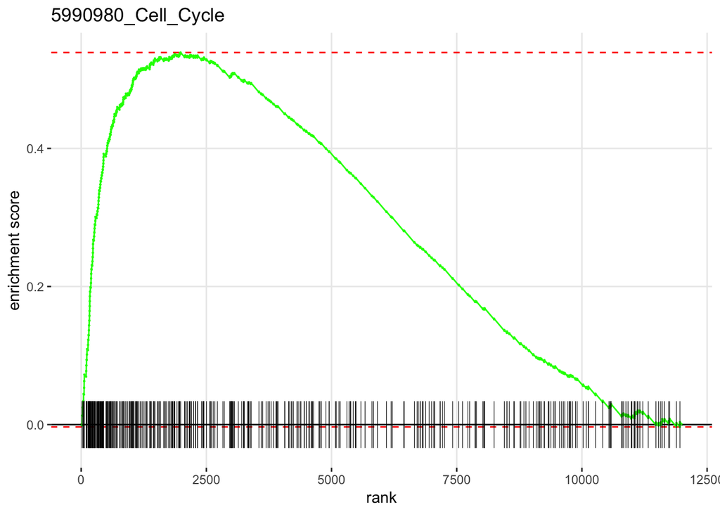

```r
# plot the most significantly enriched pathway
plotEnrichment(examplePathways[[head(fgseaRes[order(pval), ], 1)$pathway]], exampleRanks) + labs(title=head(fgseaRes[order(pval), ], 1)$pathway)
```

Plot the top 10 pathways enriched at the top and bottom of the ranked list, respectively.

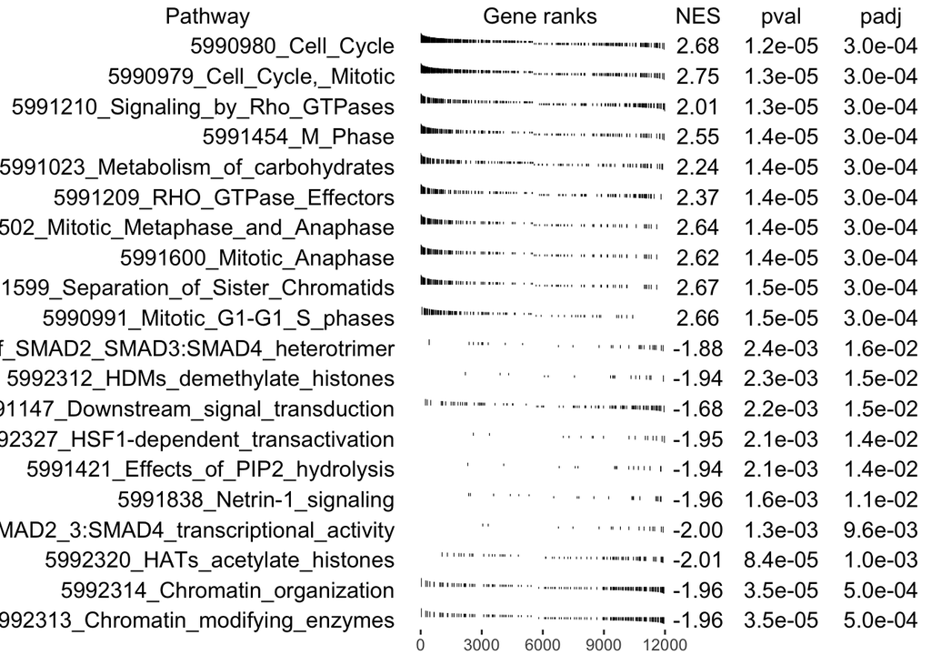

```r
topPathwaysUp <- fgseaRes[ES > 0][head(order(pval), n=10), pathway]
topPathwaysDown <- fgseaRes[ES < 0][head(order(pval), n=10), pathway]
topPathways <- c(topPathwaysUp, rev(topPathwaysDown))
plotGseaTable(examplePathways[topPathways], exampleRanks, fgseaRes, gseaParam = 0.5)
```

**Questions**:

Run and read the above code and answer:

- What is the input of function `fgsea`? With a new RNA-seq dataset, how can you generate the input for GSEA analysis?
- Can you plot top 5 most significantly enriched pathway? From the plot above are there similar pathways in the table (checking the names)? Are there any overlapped genes in first and second most significantly enriched pathway? What is the problem here? How can you improve?

# Problem 4: Differential exon usage

The DEXSeq package offers differential testing of exon usage within each gene.

First let us install packages that will be used in the analysis.

```r
## try http:// if https:// URLs are not supported
source("https://bioconductor.org/biocLite.R")
biocLite(c("pasilla", "DEXSeq"))
```

The pasilla package contains counts from an experiment by Brooks et al.

We will run DEXSeq on a subset of the genes, for demonstration purposes.

```r
library("pasilla")
inDir = system.file("extdata", package="pasilla", mustWork=TRUE)
countFiles = list.files(inDir, pattern="fb.txt$", full.names=TRUE)
flattenedFile = list.files(inDir, pattern="gff$", full.names=TRUE)
genesForSubset = read.table(file.path(inDir, "geneIDsinsubset.txt"),
  stringsAsFactors=FALSE)[[1]]
```

As in DESeq2 we use a sampleTable to define the samples:

```r
sampleTable = data.frame(
  row.names = c( "treated1", "treated2", "treated3",
    "untreated1", "untreated2", "untreated3", "untreated4" ),
  condition = c("knockdown", "knockdown", "knockdown",
    "control", "control", "control", "control" ),
  libType = c( "single-end", "paired-end", "paired-end",
    "single-end", "single-end", "paired-end", "paired-end" ) )
sampleTable
```

```
##            condition    libType
## treated1   knockdown single-end
## treated2   knockdown paired-end
## treated3   knockdown paired-end
## untreated1   control single-end
## untreated2   control single-end
## untreated3   control paired-end
## untreated4   control paired-end
```

We now read the data into a DEXSeqDataSet object:

```r
library("DEXSeq")
dxd = DEXSeqDataSetFromHTSeq(
  countFiles,
  sampleData=sampleTable,
  design= ~ sample + exon + condition:exon,
  flattenedfile=flattenedFile )
```

Subset the genes, for demonstration purposes:

```r
dxd = dxd[geneIDs( dxd ) %in% genesForSubset,]
```

Now we run the estimation and testing functions:

```r
dxd = estimateSizeFactors( dxd )
dxd = estimateDispersions( dxd )
```

```
## using supplied model matrix
## using supplied model matrix
```

```r
dxd = testForDEU( dxd )
```

```
## using supplied model matrix
```

```r
dxd = estimateExonFoldChanges( dxd, fitExpToVar="condition")
```

The following code extracts a results table, makes an MA-plot, and draws the expression levels over the exons to highlight differential exon usage:

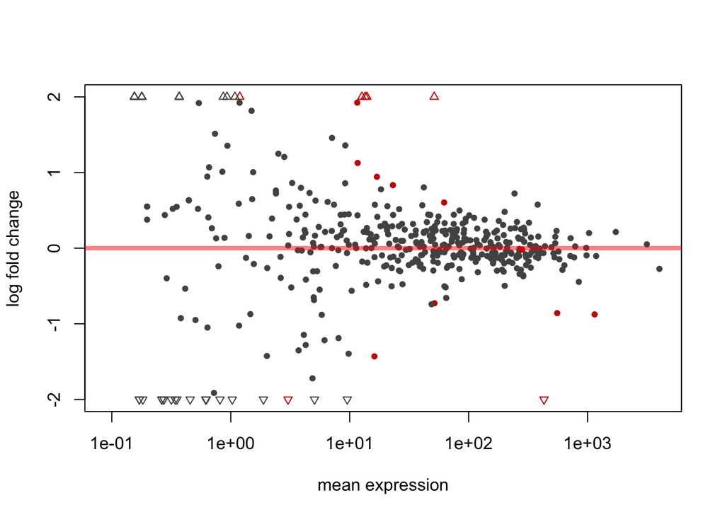

```r
dxr = DEXSeqResults( dxd )
plotMA( dxr, cex=0.8 )
```

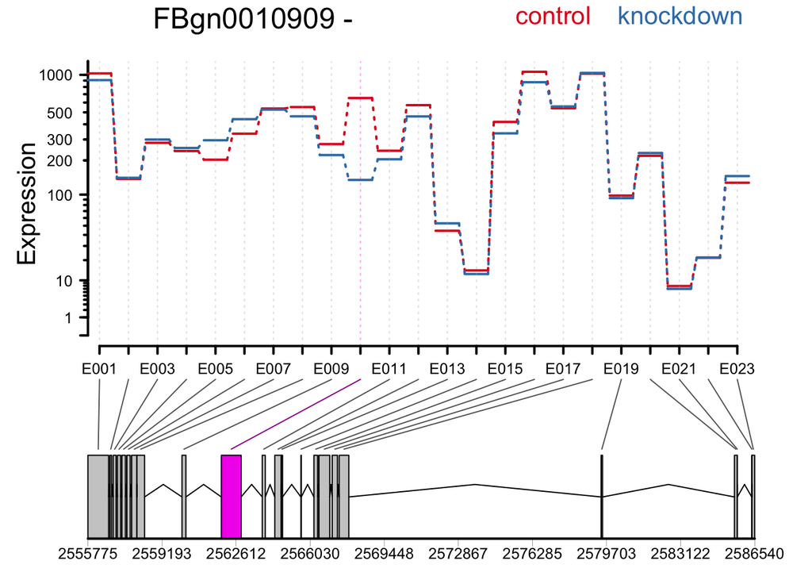

```r
plotDEXSeq( dxr, "FBgn0010909", legend=TRUE, cex.axis=1.2, cex=1.3, lwd=2 )
```

Again, drawing the expression levels, now showing the annotated transcripts below:

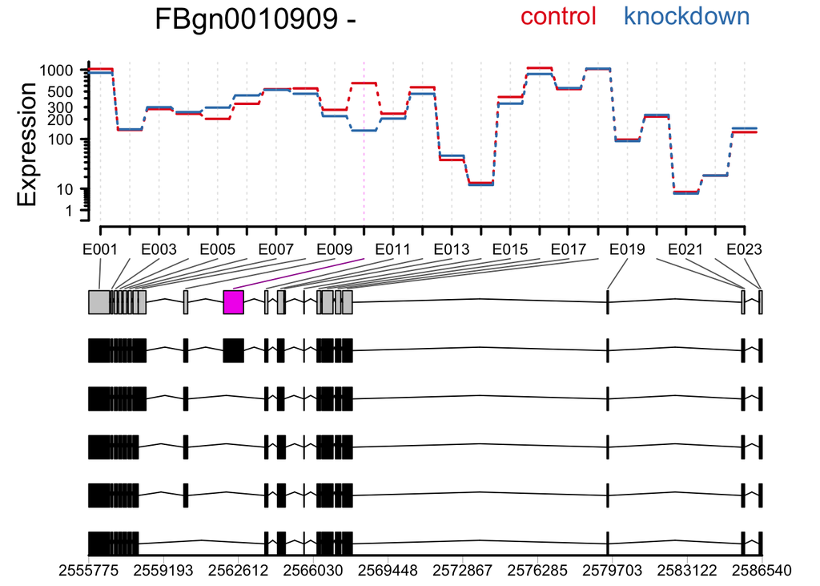

```r
plotDEXSeq( dxr, "FBgn0010909", displayTranscripts=TRUE, legend=TRUE,
              cex.axis=1.2, cex=1.3, lwd=2 )
```

**Questions**:

Run and read the above code and answer:

- What is the difference between differential exon usage and differential gene expression analysis?
- What is the input of differential exon usage? With a new RNA-seq dataset, how can you generate the input for differential exon usage?
- Can you perform differential exon usage analysis for all genes in the dataset? How many significant differential exon usage do you identify? Can you make plot for top 3 genes?

## Reference

This homework contains online materials written by Rafael Irizarry and Dave Tang.